# IODS course project

due to the different dimensions of each variable, it is hard to compute the influence of eac one and compare them reliably. Therefore, we present a summary of the scaled variables.

```r
boston_scaled <- Boston %>%
  scale %>%
  as.data.frame

summary(boston_scaled)
```

```
##       crim                 zn               indus              chas
##  Min.   :-0.419367   Min.   :-0.48724   Min.   :-1.5563   Min.   :-0.2723
##  1st Qu.:-0.410563   1st Qu.:-0.48724   1st Qu.:-0.8668   1st Qu.:-0.2723
##  Median :-0.390280   Median :-0.48724   Median :-0.2109   Median :-0.2723
##  Mean   : 0.000000   Mean   : 0.00000   Mean   : 0.0000   Mean   : 0.0000
##  3rd Qu.: 0.007389   3rd Qu.: 0.04872   3rd Qu.: 1.0150   3rd Qu.:-0.2723
##  Max.   : 9.924110   Max.   : 3.80047   Max.   : 2.4202   Max.   : 3.6648
##       nox                rm               age               dis
##  Min.   :-1.4644   Min.   :-3.8764   Min.   :-2.3331   Min.   :-1.2658
##  1st Qu.:-0.9121   1st Qu.:-0.5681   1st Qu.:-0.8366   1st Qu.:-0.8049
##  Median :-0.1441   Median :-0.1084   Median : 0.3171   Median :-0.2790
##  Mean   : 0.0000   Mean   : 0.0000   Mean   : 0.0000   Mean   : 0.0000
##  3rd Qu.: 0.5981   3rd Qu.: 0.4823   3rd Qu.: 0.9059   3rd Qu.: 0.6617
##  Max.   : 2.7296   Max.   : 3.5515   Max.   : 1.1164   Max.   : 3.9566
##       rad               tax             ptratio            black
##  Min.   :-0.9819   Min.   :-1.3127   Min.   :-2.7047   Min.   :-3.9033
##  1st Qu.:-0.6373   1st Qu.:-0.7668   1st Qu.:-0.4876   1st Qu.: 0.2049
##  Median :-0.5225   Median :-0.4642   Median : 0.2746   Median : 0.3808
##  Mean   : 0.0000   Mean   : 0.0000   Mean   : 0.0000   Mean   : 0.0000
##  3rd Qu.: 1.6596   3rd Qu.: 1.5294   3rd Qu.: 0.8058   3rd Qu.: 0.4332
##  Max.   : 1.6596   Max.   : 1.7964   Max.   : 1.6372   Max.   : 0.4406
##      lstat              medv
##  Min.   :-1.5296   Min.   :-1.9063
##  1st Qu.:-0.7986   1st Qu.:-0.5989
##  Median :-0.1811   Median :-0.1449
##  Mean   : 0.0000   Mean   : 0.0000
##  3rd Qu.: 0.6024   3rd Qu.: 0.2683
##  Max.   : 3.5453   Max.   : 2.9865
```

Now we can compare between them and say that **crime** presents the biggest range of scaled data and we can start analyzing the scaled effects of each variable over the **crime rate**.

First we separate the **crime** variable in quartiles and assign the *low*, *med-low*, *med-high*, and *high* labels to each quartile.

```r
bins <- quantile(boston_scaled$crim) # binning in quartiles

crime <- boston_scaled$crim %>%
  cut(breaks = bins,
      include.lowest = TRUE,
      labels = c("low", "med_low", "med_high", "high"))
```

We now substitute the numeric **crime** variable for the binned quartiles.

```r
boston_qt <- boston_scaled %>%
  mutate(crim = crime)
```

Once we have the factor variable, it is time to generate our training and testing data sets. Our training data set will be used to generate an explanatory model for our target variable **crime**. The model will be applied to the test data to predict the outcome. Note that the sampling is random, so each iteration of this testing might give slightly different models.

```r
set.seed(123) # to maintain random variables

n <- nrow(boston_qt)

ind <- sample(n,  size = n * 0.8)

train <- boston_qt[ind,]

test <- boston_qt[-ind,]
```

Save and remove the **crime** levels from the testing data.

```r
correct_classes <- test$crim

test <- dplyr::select(test, -crim)
```

And now we are ready to do our linear discriminant analysis (LDA). LDA is a classification method used for the modelling of categorical variables. Let’s remember that this model assumes normality of the variables and that is why we do the scaling first. Additionally, variables should be continuous, but for this exercise we can ignore **chas**.

```r
lda.fit <- lda(crim ~ ., data = train)

lda.fit
```

```
## Call:
## lda(crim ~ ., data = train)
##
## Prior probabilities of groups:
##       low   med_low  med_high      high
## 0.2549505 0.2500000 0.2500000 0.2450495
##
## Group means:
##                   zn      indus        chas        nox          rm        age
## low       1.01866313 -0.9066422 -0.08120770 -0.8835724  0.38666334 -0.9213895
## med_low  -0.07141687 -0.3429155  0.03952046 -0.5768545 -0.09882533 -0.3254849
## med_high -0.40148591  0.2162741  0.19544522  0.3637157  0.12480815  0.4564260
## high     -0.48724019  1.0149946 -0.03371693  1.0481437 -0.47733231  0.8274496
##                 dis        rad        tax    ptratio      black        lstat
## low       0.9094324 -0.6819317 -0.7458486 -0.4234280  0.3729083 -0.766883775
## med_low   0.3694282 -0.5395408 -0.4205644 -0.1079710  0.3103406 -0.164921798
## med_high -0.3720478 -0.4349280 -0.3191090 -0.2716959  0.1049654  0.009720124
## high     -0.8601246  1.6596029  1.5294129  0.8057784 -0.6383964  0.900379309
##                 medv
## low       0.47009410
## med_low   0.01548761
## med_high  0.19440747
## high     -0.71294711
##
## Coefficients of linear discriminants:
##                  LD1         LD2        LD3
## zn       0.148390645  0.74870532 -1.0874785
## indus    0.040971465 -0.38126652 -0.1619456
## chas     0.002460776  0.03963849  0.1699312
## nox      0.312458150 -0.67564471 -1.3104018
## rm       0.011086947 -0.16058718 -0.1572603
## age      0.283482486 -0.38817624 -0.1013491
## dis     -0.079848789 -0.38493775  0.2108038
## rad      3.718978412  0.93123532 -0.4706522
## tax     -0.015197127  0.04230505  1.2889075
## ptratio  0.180294774 -0.01592588 -0.3558490
## black   -0.136724112  0.02948075  0.1288959
## lstat    0.145739238 -0.37823065  0.3345688
## medv     0.061327205 -0.53906503 -0.1509890
##
## Proportion of trace:
##    LD1    LD2    LD3
## 0.9523 0.0364 0.0113
```

The following code takes the coefficients to draw arrows representing the size of the effect of the scaled valuable over the model and applies it to the plot below as arrows.

```r
lda.arrows <- function(x, myscale = 1, arrow_heads = 0.1, color = "orange", tex = 0.75, choices = c(1,2)){
  heads <- coef(x)
  arrows(x0 = 0, y0 = 0,
         x1 = myscale * heads[,choices[1]],
         y1 = myscale * heads[,choices[2]], col=color, length = arrow_heads)
  text(myscale * heads[,choices], labels = row.names(heads),
       cex = tex, col=color, pos=3)
}
```

We change the **crime** variable in our training data set to a numeric vector.

```r
classes <- as.numeric(train$crim)
```

We plot the LDA fitted model (LD1 vs LD2) and separate each class using colors and figures. We also run the function to draw the arrows.

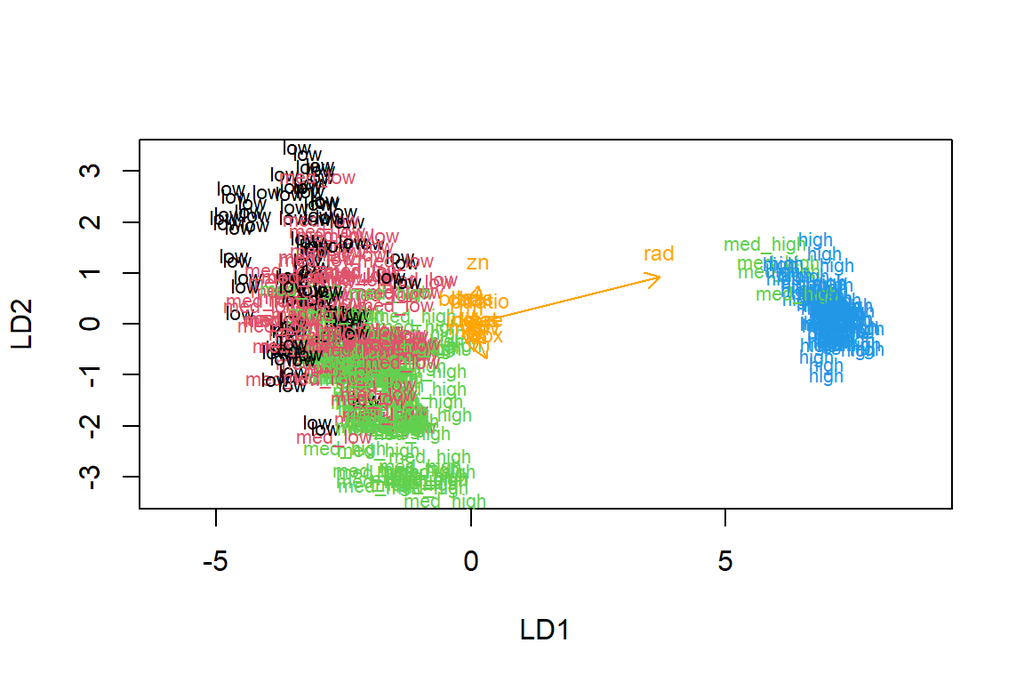

```r
plot(lda.fit, dimen = 2, col = classes, pch = classes)
lda.arrows(lda.fit, myscale = 1)
```

We can observe that **rad** has the biggest influence over the separation of the model. Furthermore, its influence is mostly explained by the LD1. This means that the changes in the rad variable are more likely to influence the **crime rate** into a *high* value.

Now we can test the predictive power of this model over the test data set and create a table to compare the results with those stored in *correct_classes*.

```r
lda.pred <- predict(lda.fit, newdata = test)
table(correct = correct_classes, predicted = lda.pred$class)
```

```
##           predicted
## correct    low med_low med_high high
##   low       10      10        4    0
##   med_low    2      17        6    0
##   med_high   1       9       13    2
##   high       0       0        1   27
```

We can now apply the same loss function we used before to asses the proportion of wrong predictions.

```r
loss_func <- function(class, prob) {
  n_wrong <- abs(class - prob) > 0.5
  mean(n_wrong)
}

loss_func(as.numeric(correct_classes),as.numeric(lda.pred$class))
```

```
## [1] 0.3431373
```

We can see the 34% of the predictions were not correct.

For the next part of the analysis, we will observe the different ways of comparing the similarity of the different towns. We will use both euclidean and Manhattan distances. Euclidean is simple the geometric distance between two points, while Manhattan distance observes the absolute differences between the coordinates of two points.

First we measure the euclidean distance:

```r
data("Boston")

boston_scaled <- Boston %>%
  scale %>%
  as.data.frame

dist_eu <- dist(boston_scaled)
summary(dist_eu)
```

```
##    Min. 1st Qu.  Median    Mean 3rd Qu.    Max.
##  0.1343  3.4625  4.8241  4.9111  6.1863 14.3970
```

and the Manhattan distance as well:

```r
dist_man <- dist(boston_scaled, method = 'manhattan')
summary(dist_man)
```

```
##    Min. 1st Qu.  Median    Mean 3rd Qu.    Max.
##  0.2662  8.4832 12.6090 13.5488 17.7568 48.8618
```

These two distance are applied to clustering protocols by minimizing the distance between the observatoions.

One example of such clustering protocols is the k-means clustering. Note that, contrary to the LDA classification method, the clustering is an unsupervised method that does not have the final classification determined *a priori*. Also remember that the distance measuring method will change the output of your clustering.

So now we run the k-means clustering method on the scaled data starting by three centroids.

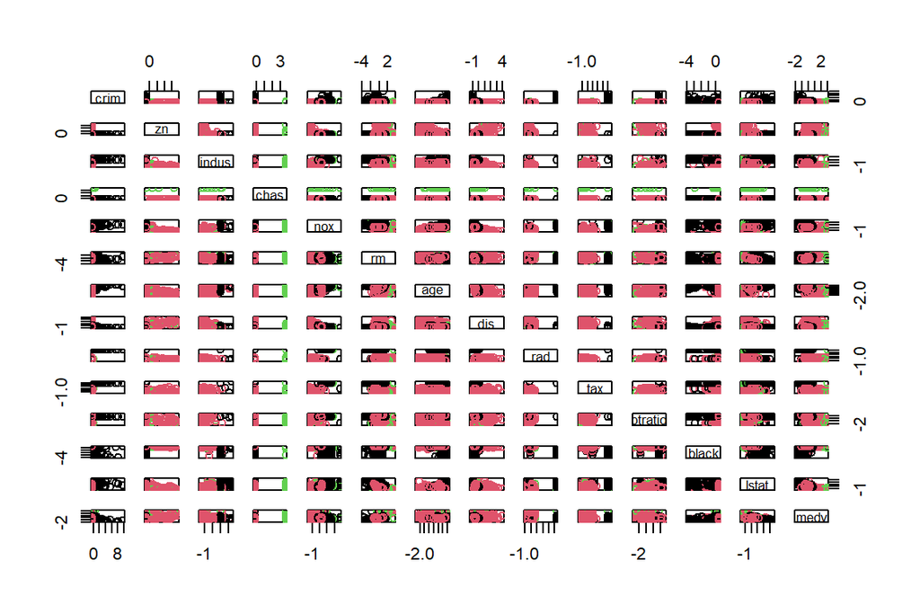

```r
km <- kmeans(boston_scaled, centers = 3)

pairs(boston_scaled, col = km$cluster)
```

In the plot we can observe how the distribution into the clusters separates the data in the pairwise scatter plots. But this was just a guessed number of centroids. We can optimize this by using the within cluster sum of squares (WCSS).

We will run the k-means clustering method changing th number of clusters from 1 to 10. We will take the WCSS (i.e. variance between the obs in a cluster and the center of that cluster) and compare it as the number of centers increases.

so first we run all the different k in 1:10, and store the total WCSS (TWCSS)

```r
set.seed(123) # to maintain the result of random variables.
k_max <- 10
twcss <- sapply(1:k_max, function(k){kmeans(Boston, k)$tot.withinss})
```

Now we plot the TWCSS’s vs the number of centers.

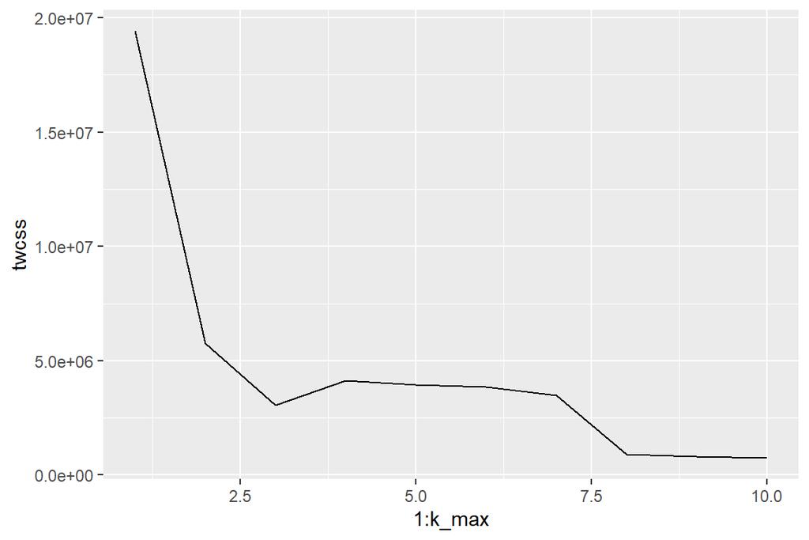

```r
qplot(x = 1:k_max, y = twcss, geom = 'line')
```

We can see that the biggest change occurs between 1 and 2 centers. We will try now the clustering with two centers.

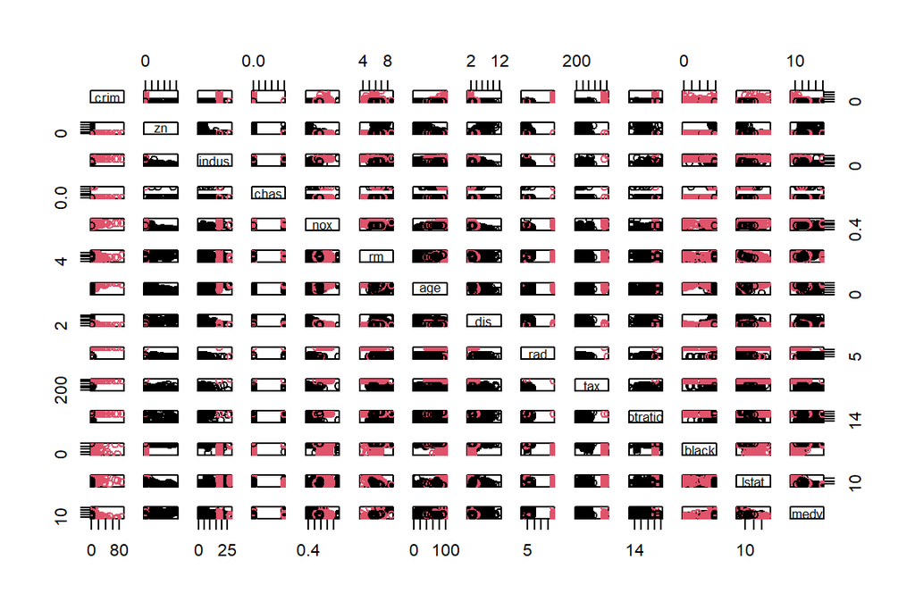

```r
km <- kmeans(Boston, centers = 2)
pairs(Boston, col = km$cluster)
```

As we observe the scatter plots we can appreciate that the groups ar better defined then when using 3 centers. Therefore, 2 centers is our optimal k for our clustering analysis.

For the bonus points: LDA on k-means

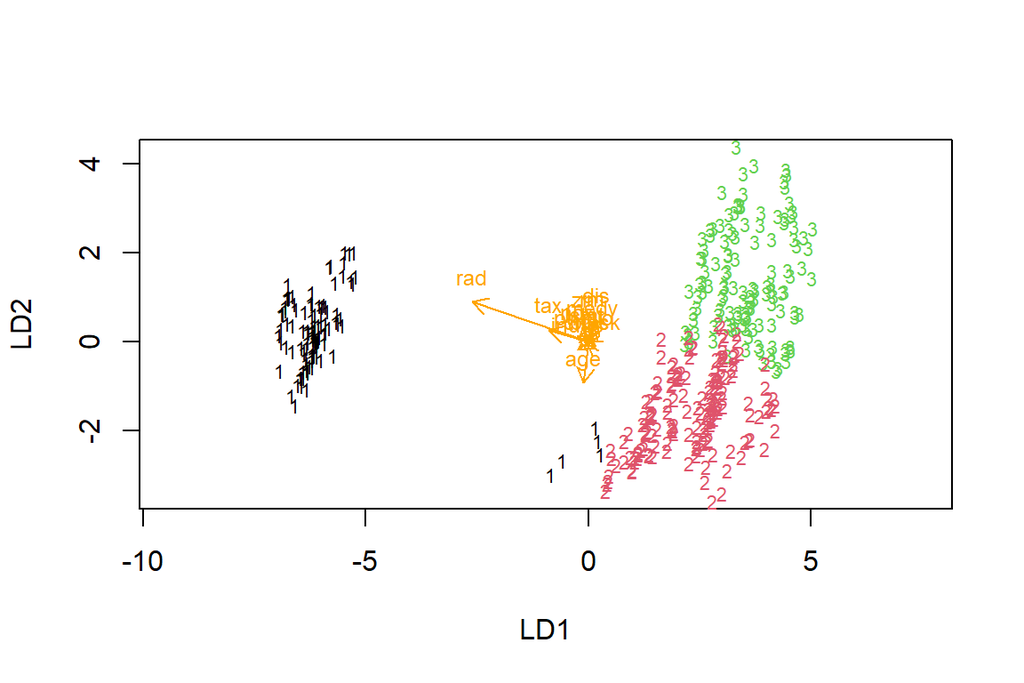

```r
data("Boston")

boston_scaled <- Boston %>%
  scale %>%
  as.data.frame

set.seed(123) # to maintain random variables

km <- kmeans(boston_scaled, centers = 3)

boston_km <- boston_scaled %>%
  mutate(crim = as.factor(km$cluster))

n <- nrow(boston_km)

ind <- sample(n,  size = n * 0.8)

train <- boston_km[ind,]

test <- boston_km[-ind,]

correct_classes <- test$crim

test <- dplyr::select(test, -crim)

lda.fit <- lda(crim ~ ., data = train)

classes <- as.numeric(train$crim)

plot(lda.fit, dimen = 2, col = classes, pch = classes)
lda.arrows(lda.fit, myscale = 1)
```

We can observe that **rad** remains the biggest influence over the separation of the model. Furthermore, its influence is mostly explained by the LD1 again. This means that the changes in the **rad** variable are more likely to influence the **crime rate** into a *1* cluster. Then **age** seems to have the next most influential value. **Age** seems to mostly separate cluster 2 and 3 in the LD2 axis.

## Chapter 5: Dimensionality reduction techniques

```r
date()
```

```
## [1] "Sun Dec 05 19:46:52 2021"
```

Here we go again…

Remember! Set your working directory and load your libraries.

```r
knitr::opts_knit$set(root.dir ="C:/Users/ramosgon/OneDrive - University of Helsinki/Courses/OpenDataScience/IODS-project/Data")

library(tidyverse)
library(car)
library(GGally)
library(FactoMineR)
```

We read the data.

```r
human <- read.csv("human_base.csv", header = T, sep = ",")
```

The Human Development Index (HDI) is a summary measure of average achievement of a country in human development such as a long and healthy life with a decent standard of living. The HDI is the geometric mean of normalized indices that represent theHuman Development separated into three categories. The Gender Inequality Index (GII) reflects gender-based disadvantage based on reproductive health, empowerment and the labor market. GII is shown together with HDI to show the difference in human development between genders due to inequality between female and male achievements. The following data sets consolidate the HDI and GII indicators (17) for 195 countries. For more information on the topic, visit the following links:

http://hdr.undp.org/sites/default/files/hdr2015_technical_notes.pdf

http://hdr.undp.org/en/content/human-development-index-hdi

First we re-format the **GNI** to contain numbers intead of char.

```r
human$GNI <- human$GNI %>%
  gsub(",","", x = .) %>%
  as.numeric
```

We select the variables of interest for our study and remove those country that are missing any of the indexes (i.e. NA’s).

```r
keep <- c("Country", "Edu2.FM", "Labo.FM", "Edu.Exp", "Life.Exp",
          "GNI", "Mat.Mor", "Ado.Birth", "Parli.F")

human <- human %>%
  dplyr::select(one_of(keep))

human_ <- human %>%
  filter(complete.cases(human))
```

Looking at the tail of the table, we can notice that the last seven observations are regions instead of countries. Therefore, we remove them as we change the country names into the row names.

```r
tail(human_, 10)
```

```
##                             Country   Edu2.FM   Labo.FM Edu.Exp Life.Exp   GNI
## 153                            Chad 0.1717172 0.8080808     7.4     51.6  2085
## 154        Central African Republic 0.3782772 0.8531140     7.2     50.7   581
## 155                           Niger 0.3076923 0.4459309     5.4     61.4   908
## 156                     Arab States 0.7289916 0.3081009    12.0     70.6 15722
## 157       East Asia and the Pacific 0.8250377 0.7884131    12.7     74.0 11449
## 158         Europe and Central Asia 0.8784119 0.6514286    13.6     72.3 12791
## 159 Latin America and the Caribbean 0.9836957 0.6729323    14.0     75.0 14242
## 160                      South Asia 0.5329670 0.3711083    11.2     68.4  5605
## 161              Sub-Saharan Africa 0.7015873 0.8537859     9.6     58.5  3363
## 162                           World 0.8333333 0.6558018    12.2     71.5 14301
##     Mat.Mor Ado.Birth Parli.F
## 153     980     152.0    14.9
## 154     880      98.3    12.5
## 155     630     204.8    13.3
## 156     155      45.4    14.0
## 157      72      21.2    18.7
## 158      28      30.8    19.0
## 159      85      68.3    27.0
## 160     183      38.7    17.5
## 161     506     109.7    22.5
## 162     210      47.4    21.8
```

```r
last <- nrow(human_) - 7

human_ <- human_[1:last, ]

rownames(human_) <- human_$Country

human <- human_[,-1]
```

Now we can take a look at the data. With 155 countries remaining,we will be studying the interactions of 8 continuous variables of int or num type.

```r
dim(human)
```

```
## [1] 155   8
```

```r
str(human)
```

```
## 'data.frame':    155 obs. of  8 variables:
##  $ Edu2.FM  : num  1.007 0.997 0.983 0.989 0.969 ...
##  $ Labo.FM  : num  0.891 0.819 0.825 0.884 0.829 ...
##  $ Edu.Exp  : num  17.5 20.2 15.8 18.7 17.9 16.5 18.6 16.5 15.9 19.2 ...
##  $ Life.Exp : num  81.6 82.4 83 80.2 81.6 80.9 80.9 79.1 82 81.8 ...
##  $ GNI      : num  64992 42261 56431 44025 45435 ...
##  $ Mat.Mor  : int  4 6 6 5 6 7 9 28 11 8 ...
##  $ Ado.Birth: num  7.8 12.1 1.9 5.1 6.2 3.8 8.2 31 14.5 25.3 ...
##  $ Parli.F  : num  39.6 30.5 28.5 38 36.9 36.9 19.9 19.4 28.2 31.4 ...
```

```r
summary(human)
```

```
##     Edu2.FM          Labo.FM          Edu.Exp         Life.Exp
##  Min.   :0.1717   Min.   :0.1857   Min.   : 5.40   Min.   :49.00
##  1st Qu.:0.7264   1st Qu.:0.5984   1st Qu.:11.25   1st Qu.:66.30
##  Median :0.9375   Median :0.7535   Median :13.50   Median :74.20
##  Mean   :0.8529   Mean   :0.7074   Mean   :13.18   Mean   :71.65
##  3rd Qu.:0.9968   3rd Qu.:0.8535   3rd Qu.:15.20   3rd Qu.:77.25
##  Max.   :1.4967   Max.   :1.0380   Max.   :20.20   Max.   :83.50
##       GNI            Mat.Mor         Ado.Birth         Parli.F
##  Min.   :   581   Min.   :   1.0   Min.   :  0.60   Min.   : 0.00
##  1st Qu.:  4198   1st Qu.:  11.5   1st Qu.: 12.65   1st Qu.:12.40
##  Median : 12040   Median :  49.0   Median : 33.60   Median :19.30
##  Mean   : 17628   Mean   : 149.1   Mean   : 47.16   Mean   :20.91
##  3rd Qu.: 24512   3rd Qu.: 190.0   3rd Qu.: 71.95   3rd Qu.:27.95
##  Max.   :123124   Max.   :1100.0   Max.   :204.80   Max.   :57.50
```

As in the last chapter, it is hard to compare the range of the variables or their means and std deviations without first scaling, so lets look at them graphically first.

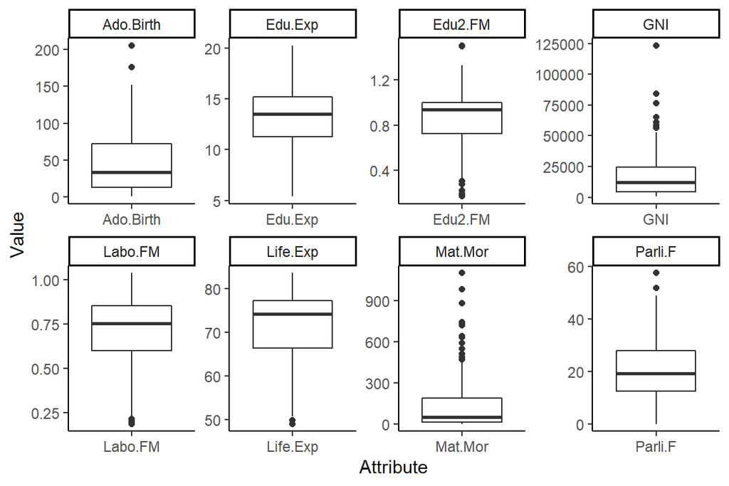

```r
human %>% rownames_to_column(var = "Country") %>%
  pivot_longer(cols = c(-1), names_to = "Attribute", values_to = "Value") %>%
  ggplot(aes(x = Attribute, y = Value)) +
  geom_boxplot() +
  facet_wrap("Attribute", scales = "free", nrow = 2) +
  theme_classic()
```

Let us use the qqplots to confirm the Normaility of these distributions.

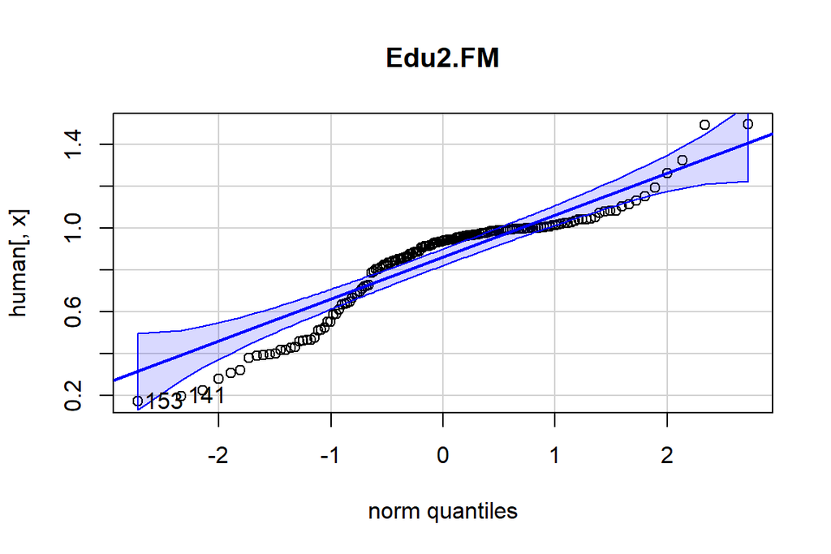

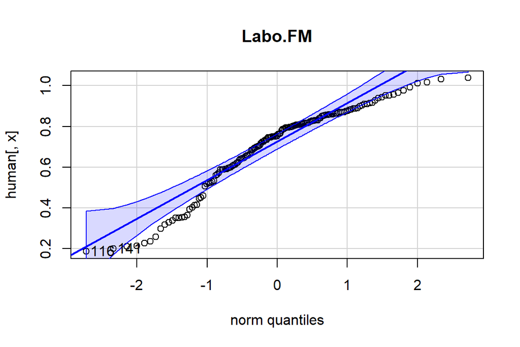

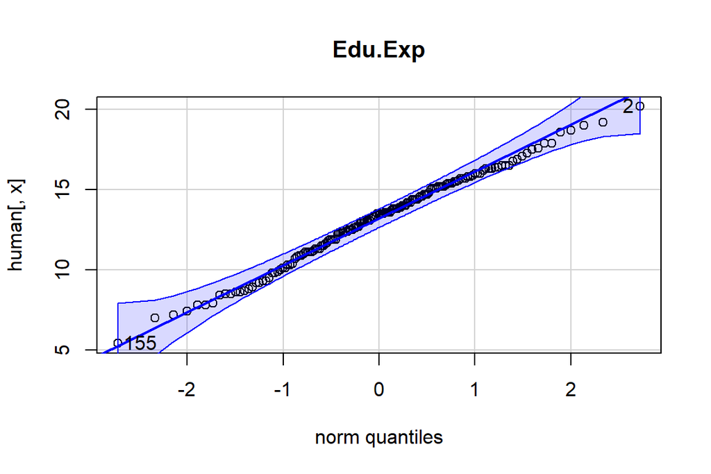

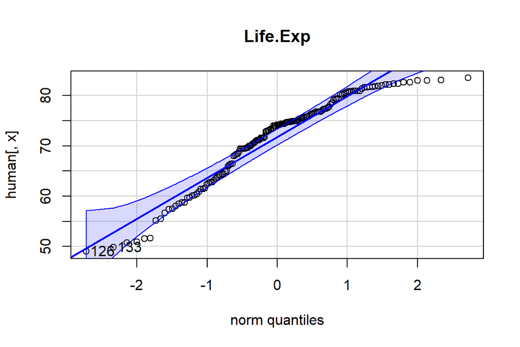

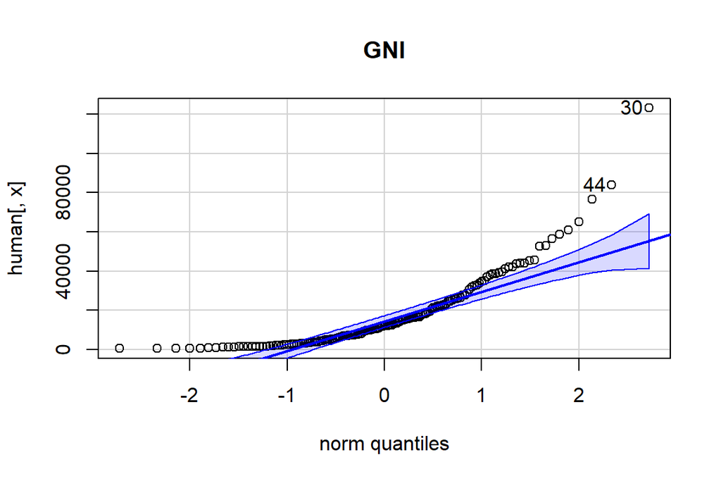

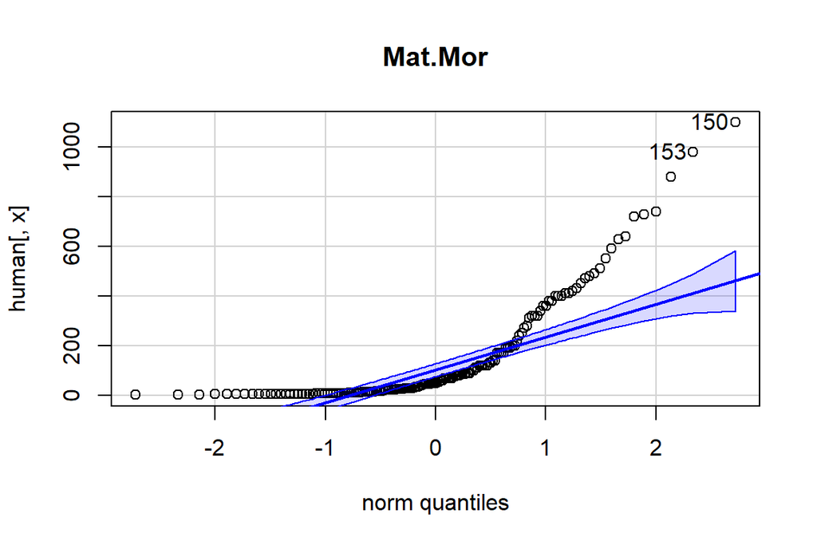

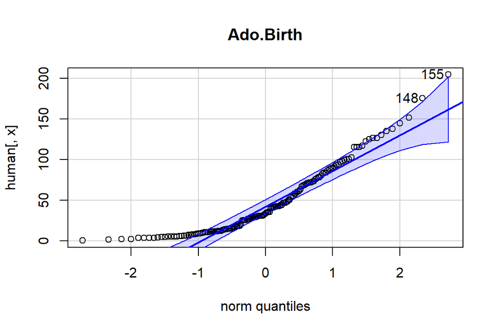

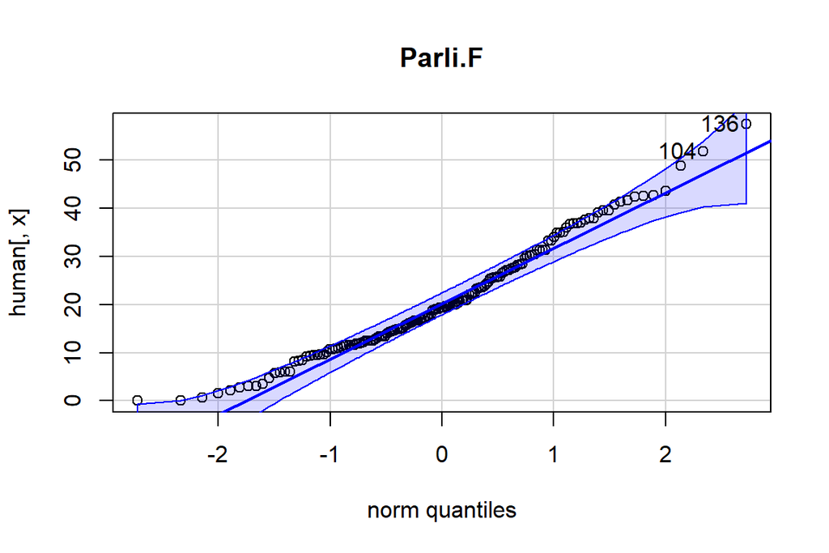

```
##      Edu2.FM Labo.FM Edu.Exp Life.Exp GNI Mat.Mor Ado.Birth Parli.F
## [1,]     153     116     155      126  30     150       155     136
## [2,]     141     141       2      133  44     153       148     104
```

```r
colnames(human) %>% sapply(function(x){
  qqPlot(human[,x], main = x)
})
```

As expected from the box plots, **GNI** and **maternal mortality** diverge from the identity line in our qqplots making their normality questionable.

To continue our analysis, we will look at the correlation coefficients. For correlation comparison, scaling is not considered necesary. Therefore, let us see the situation when the values are not scaled.

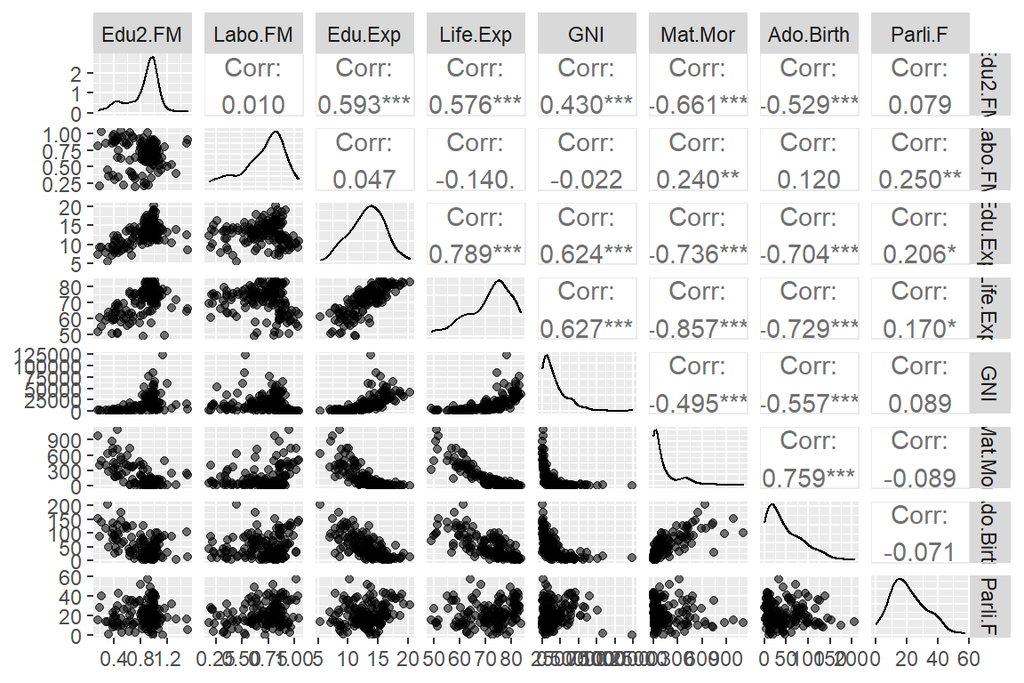

```r
human %>%
  ggpairs(mapping = aes(alpha = 0.3))
```

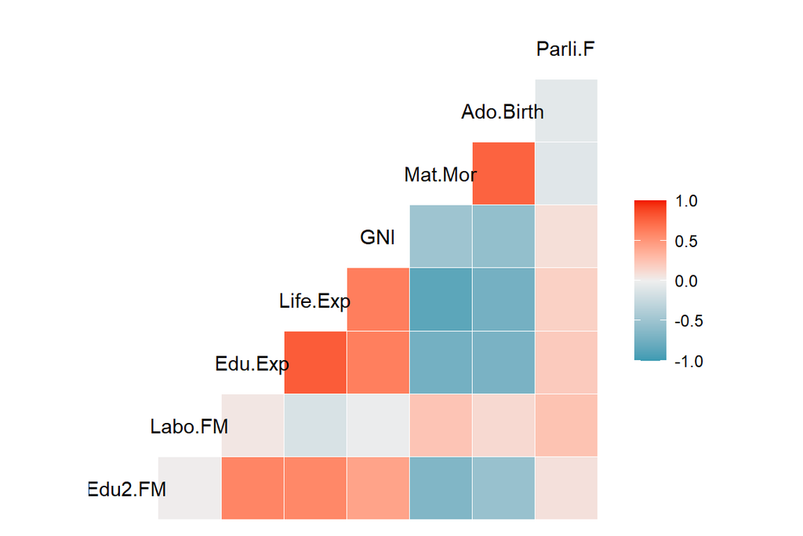

```r
human %>%
  ggcorr(method = c("everything", "pearson"))
```

From here we can see:

- **Maternal mortality** and **life expectancy** show the highest correlation which happens to be negative. This makes sense, since the lack of health development would clearly be reflected by low healthcare availability or quality, and, thus, higher mortality rates and lower **life expectancy**.
- **Expected education** and **life expectancy** show the next highest correlation, but positive this time.

We could keep discussing the correlation between variables, but due to the high complexity of the model due to the amount of variables we might reach unclear conclusions. Therefore, we will use a dimensionality reduction technique. Principal component analysis or PCA lets us focus in the main dimensions that provide the explanation for most of the variation in the data points. PCA starts by defining a dimension in which the distance between the points is maximized. This will be our first principal component since it accounts for most of the variation. From then on, the algorithm continues looking for the dimensions that maximize the remaing distances. The catch is that starting on the second principal component, this dimension must be orthogonal to the last one. For further details on PCA watch this [video](https://www.youtube.com/watch?v=FgakZw6K1QQ) which I love.

So lets go at it. Note that I have not scaled the values yet.

```r
pca_human <- prcomp(human)

s <- summary(pca_human)
s
```

```
## Importance of components:
##                              PC1      PC2   PC3   PC4   PC5   PC6    PC7    PC8
## Standard deviation     1.854e+04 185.5219 25.19 11.45 3.766 1.566 0.1912 0.1591
## Proportion of Variance 9.999e-01   0.0001  0.00  0.00 0.000 0.000 0.0000 0.0000
## Cumulative Proportion  9.999e-01   1.0000  1.00  1.00 1.000 1.000 1.0000 1.0000
```

From the summary table you can notice that PC1 accounts for 99.99% of the variance. With this result, we *know* that this dimension explains all of the variance so **Hurray!**.

Wait, there is a catch. Let us look at the graphical representation of the first 2 PCs in a biplot compared to the size of each variables influence (the size will be represented by pink arrows that show the projection of each variables axix unto the 2-D plain created between PC1 and PC2).

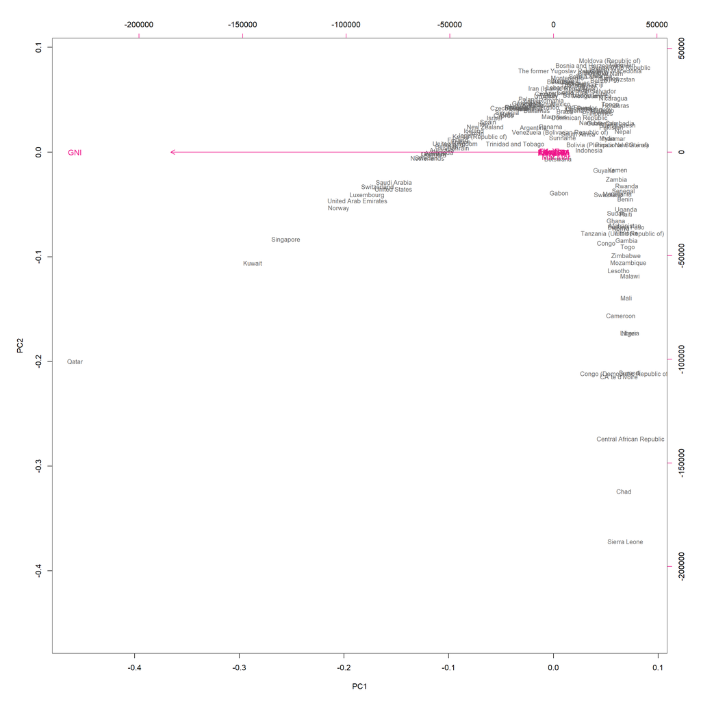

```r
pca_pr <- round(100*s$importance[2,], digits = 2)

biplot(pca_human, choices = 1:2, cex = c(0.8, 1), col = c("grey40", "deeppink2"))
```

Since PCA works by maximizing variance, we have to scale the variables for the analysis to be worthwhile.So here we go with the scaled data.

```r
human_std <- scale(human)

pca_human <- prcomp(human_std)

s <- summary(pca_human)
s
```

```
## Importance of components:
##                           PC1    PC2     PC3     PC4     PC5     PC6     PC7
## Standard deviation     2.0708 1.1397 0.87505 0.77886 0.66196 0.53631 0.45900
## Proportion of Variance 0.5361 0.1624 0.09571 0.07583 0.05477 0.03595 0.02634
## Cumulative Proportion  0.5361 0.6984 0.79413 0.86996 0.92473 0.96069 0.98702
##                            PC8
## Standard deviation     0.32224
## Proportion of Variance 0.01298
## Cumulative Proportion  1.00000
```

Much better, now we can see how the distribution of the variation is spread between the different PCs. But let us look at PC1 and PC2 since they account for almost 70% of the variation.

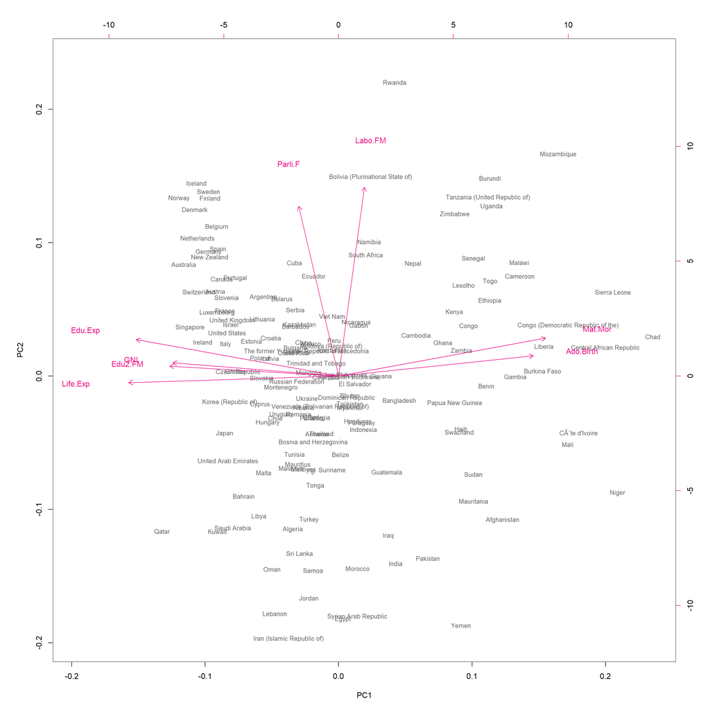

```r
pca_pr <- round(100*s$importance[2,], digits = 2)

biplot(pca_human, choices = 1:2, cex = c(0.8, 1), col = c("grey40", "deeppink2"))
```

Now we can see that:

- **Maternal mortality** and **adolescent birth rates** do show a close relationship as their projections over the 2 first PCs are very similar. additionally, they are almost parallel to PC1 and almost opposed to **life expectancy**. Furthermore, we can observe that countries in the furthermost right section of the plot belong mostly to the African continent.
- On the top left corner we can se the Nordics. According to the size projections of the variables,these countries would have the highest **GNI**, **expected education**, **life expectancy**, **female over male secondary education ratio**, **female in parliament**, and **female over male secondary education ratio**.

Since it is not my are of expertise I would rather not make very insightful observations, but there does seem to be a relation between the developed countries and their human development versus developing countries.

For data sets with categorical data, the MCA is a good alternative to the PCA. Here we call for the **tea** data set from the **Factominer** package.

```r
data(tea)

dim(tea)
```

```
## [1] 300  36
```

```r
str(tea)
```

```
## 'data.frame':    300 obs. of  36 variables:
##  $ breakfast       : Factor w/ 2 levels "breakfast","Not.breakfast": 1 1 2 2 1 2 1 2 1 1 ...
##  $ tea.time        : Factor w/ 2 levels "Not.tea time",..: 1 1 2 1 1 1 2 2 2 1 ...
##  $ evening         : Factor w/ 2 levels "evening","Not.evening": 2 2 1 2 1 2 2 1 2 1 ...
##  $ lunch           : Factor w/ 2 levels "lunch","Not.lunch": 2 2 2 2 2 2 2 2 2 2 ...
##  $ dinner          : Factor w/ 2 levels "dinner","Not.dinner": 2 2 1 1 2 1 2 2 2 2 ...
##  $ always          : Factor w/ 2 levels "always","Not.always": 2 2 2 2 1 2 2 2 2 2 ...
##  $ home            : Factor w/ 2 levels "home","Not.home": 1 1 1 1 1 1 1 1 1 1 ...
##  $ work            : Factor w/ 2 levels "Not.work","work": 1 1 2 1 1 1 1 1 1 1 ...
##  $ tearoom         : Factor w/ 2 levels "Not.tearoom",..: 1 1 1 1 1 1 1 1 1 2 ...
##  $ friends         : Factor w/ 2 levels "friends","Not.friends": 2 2 1 2 2 2 1 2 2 2 ...
##  $ resto           : Factor w/ 2 levels "Not.resto","resto": 1 1 2 1 1 1 1 1 1 1 ...
##  $ pub             : Factor w/ 2 levels "Not.pub","pub": 1 1 1 1 1 1 1 1 1 1 ...
##  $ Tea             : Factor w/ 3 levels "black","Earl Grey",..: 1 1 2 2 2 2 2 1 2 1 ...
##  $ How             : Factor w/ 4 levels "alone","lemon",..: 1 3 1 1 1 1 1 3 3 1 ...
```

[output cut: 22 more lines]

```r
summary(tea)
```

```
##          breakfast           tea.time          evening          lunch
##  breakfast    :144   Not.tea time:131   evening    :103   lunch    : 44
##  Not.breakfast:156   tea time    :169   Not.evening:197   Not.lunch:256
##
##
##
##
##
##         dinner           always          home           work
##  dinner    : 21   always    :103   home    :291   Not.work:213
##  Not.dinner:279   Not.always:197   Not.home:  9   work    : 87
##
##
##
##
##
##         tearoom           friends          resto          pub
##  Not.tearoom:242   friends    :196   Not.resto:221   Not.pub:237
##  tearoom    : 58   Not.friends:104   resto    : 79   pub    : 63
##
##
##
##
##
##         Tea         How           sugar                     how
##  black    : 74   alone:195   No.sugar:155   tea bag           :170
##  Earl Grey:193   lemon: 33   sugar   :145   tea bag+unpackaged: 94
##  green    : 33   milk : 63                  unpackaged        : 36
##                  other:  9
##
##
##
##                   where                 price          age        sex
##  chain store         :192   p_branded      : 95   Min.   :15.00   F:178
##  chain store+tea shop: 78   p_cheap        :  7   1st Qu.:23.00   M:122
##  tea shop            : 30   p_private label: 21   Median :32.00
##                             p_unknown      : 12   Mean   :37.05
##                             p_upscale      : 53   3rd Qu.:48.00
##                             p_variable     :112   Max.   :90.00
##
```

[output cut: 25 more lines]

```
##  feminine    :129   Not.sophisticated: 85   No.slimming:255   exciting   :116
##  Not.feminine:171   sophisticated    :215   slimming   : 45   No.exciting:184
##
##
##
##
##
##         relaxing              effect.on.health
##  No.relaxing:113   effect on health   : 66
##  relaxing   :187   No.effect on health:234
##
##
##
##
##
```

The data used here comes from a questionnaire about tea consumption. 300 individuals were interviewed about how they drink tea (18 questions), what are their product’s perception (12 questions) and some personal details (4 questions).

Due to them being categorical variables, lets just look at the bar plots to see the distributions.

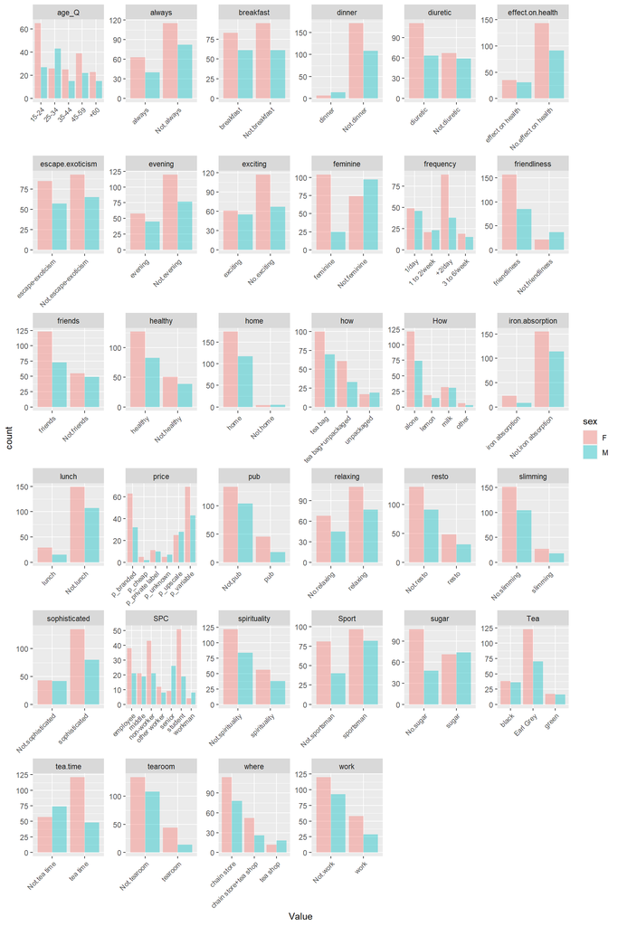

```r
tea %>%
  dplyr::select(-age) %>%
  pivot_longer(cols = c(-sex), names_to = "Attribute", values_to = "Value") %>%
  ggplot(aes(Value, fill = sex)) +
  facet_wrap("Attribute", scales = "free") +
  geom_bar(position = "dodge",alpha = 0.4) +
  theme(axis.text.x = element_text(angle = 45, hjust = 1, size = 8))
```

We can see that:

- For most variables, **gender** does not seem to affect the tea preferences of the interviewed.

Again, all of this variables can seem very overwhelming, but the MCA can simplify things. But even before that, let us select the variables involved in how they drink coffee.

```r
keep_columns <- c("Tea", "How", "how", "sugar", "where", "lunch")

tea <- dplyr::select(tea, one_of(keep_columns))
```

MCA uses frequencies instead of geometrical distances to calculate the patterns between categorical variables. It uses multi-dimentional cross tabulations of the data, There are various methods for this, like an indicator matrix or the Burt matrix. Their main idea is to separate the categorical variables into their categories and align them to the observation.

Using the inter- and intra-category variances, the algorythm will generate new dimensions that explain the most variance possible. Let’s try it.

```r
mca <- tea %>%
  MCA(graph = FALSE)

summary(mca)
```

```
##
## Call:
## MCA(X = ., graph = FALSE)
##
##
## Eigenvalues
##                        Dim.1   Dim.2   Dim.3   Dim.4   Dim.5   Dim.6   Dim.7
## Variance               0.279   0.261   0.219   0.189   0.177   0.156   0.144
## % of var.             15.238  14.232  11.964  10.333   9.667   8.519   7.841
## Cumulative % of var.  15.238  29.471  41.435  51.768  61.434  69.953  77.794
##                        Dim.8   Dim.9  Dim.10  Dim.11
## Variance               0.141   0.117   0.087   0.062
## % of var.              7.705   6.392   4.724   3.385
## Cumulative % of var.  85.500  91.891  96.615 100.000
##
## Individuals (the 10 first)
##                       Dim.1    ctr   cos2    Dim.2    ctr   cos2    Dim.3
## 1                  | -0.298  0.106  0.086 | -0.328  0.137  0.105 | -0.327
## 2                  | -0.237  0.067  0.036 | -0.136  0.024  0.012 | -0.695
## 3                  | -0.369  0.162  0.231 | -0.300  0.115  0.153 | -0.202
## 4                  | -0.530  0.335  0.460 | -0.318  0.129  0.166 |  0.211
## 5                  | -0.369  0.162  0.231 | -0.300  0.115  0.153 | -0.202
## 6                  | -0.369  0.162  0.231 | -0.300  0.115  0.153 | -0.202
## 7                  | -0.369  0.162  0.231 | -0.300  0.115  0.153 | -0.202
## 8                  | -0.237  0.067  0.036 | -0.136  0.024  0.012 | -0.695
## 9                  |  0.143  0.024  0.012 |  0.871  0.969  0.435 | -0.067
## 10                 |  0.476  0.271  0.140 |  0.687  0.604  0.291 | -0.650
##                       ctr   cos2
## 1                   0.163  0.104 |
## 2                   0.735  0.314 |
## 3                   0.062  0.069 |
## 4                   0.068  0.073 |
## 5                   0.062  0.069 |
## 6                   0.062  0.069 |
## 7                   0.062  0.069 |
## 8                   0.735  0.314 |
## 9                   0.007  0.003 |
## 10                  0.643  0.261 |
##
## Categories (the 10 first)
```

[output cut: 16 more lines]

```
## lemon                3.226 |   1.329  14.771   0.218   8.081 |
## milk                 2.422 |   0.013   0.003   0.000   0.116 |
## other                5.534 |  -2.524  14.526   0.197  -7.676 |
## tea bag             -6.941 |  -0.065   0.183   0.006  -1.287 |
## tea bag+unpackaged  11.956 |   0.019   0.009   0.000   0.226 |
## unpackaged          -6.482 |   0.257   0.602   0.009   1.640 |
##
## Categorical variables (eta2)
##                      Dim.1 Dim.2 Dim.3
## Tea                | 0.126 0.108 0.410 |
## How                | 0.076 0.190 0.394 |
## how                | 0.708 0.522 0.010 |
## sugar              | 0.065 0.001 0.336 |
## where              | 0.702 0.681 0.055 |
## lunch              | 0.000 0.064 0.111 |
```

It is much easier to interpret by looking at the graphical depiction of this analysis.

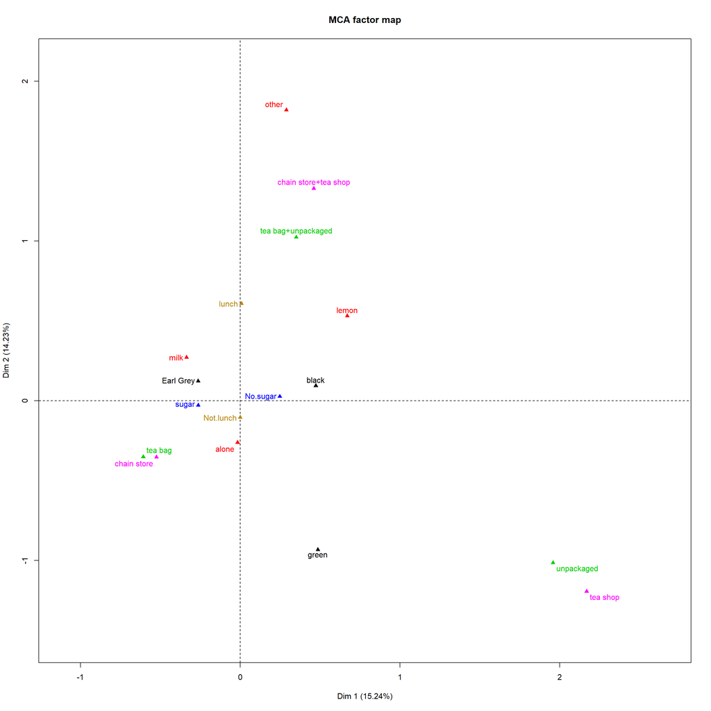

```r
plot(mca, invisible=c("ind"), habillage = "quali", graph.type = "classic")
```

Note that this is the categories plot. It will tell us which categories are closely related to each other. We can therefore concluded:

- Those buying tea bags mostly get them from chain stores, while unpacked tea drinkers usually get them from tea stores.Lastly, groups without preference for tea bags or unpacked also show no preference for buying location.
- Not lunch tea drinlkers most likely have a preference on the place and type of tea to buy then noty tea drinkers.
- Earl grey drinkers are more likely to drink tea with milk and sugar then black tea drinkers who are closer to lemon and alone tea.